# IE48B-Project

## Model Selection and Test Part

```r
dt <- fread("C:/Users/kaan9/OneDrive/Masaüstü/bulk_imbalance_son.csv")
total_vol <- data.table(dt[,c("date","hour","downRegulationZeroCoded",
                              "upRegulationZeroCoded","net","system_direction")])
colnames(total_vol) <- c("date","hour","yat_vol","yal_vol","net_imb","direction")
```

```r
wt <- fread("C:/Users/kaan9/OneDrive/Masaüstü/weather_son.csv")
wt$loc <- paste("loc",as.character(wt$lat),as.character(wt$lon),sep="_")
wt <- data.table(pivot_wider(wt[,c(1,2,7,5,6)],names_from = c(loc,variable),values_from =value))
wt$day <- wday(wt$date)
wt$month <- month(wt$date)
total_vol <- wt[total_vol,on=.(date,hour)]
total_vol$t <- 1:nrow(total_vol)
total_vol[, direction:=ifelse(net_imb>50, "Positive" , ifelse(net_imb<(-50),"Negative","Neutral"))]
total_vol[, net_imb:=ifelse(net_imb<(-5000), (-5000), ifelse(net_imb>5000, 5000, net_imb))]
```

Data is read, trend, week day and month information added as features. Then, data is transformed to wide format. There are 42 additional features from the weather data. Multivariate time series will be transformed to univariate time series with PCA and Random Forest.

```r
pca <- princomp(total_vol[,-c("date","yat_vol","yal_vol","net_imb","direction","t")])
summary(pca)
```

```
Importance of components:
                            Comp.1       Comp.2       Comp.3      Comp.4
Standard deviation     704.3836339 122.42625879 101.36671251 93.81010051
Proportion of Variance   0.8474425   0.02560005   0.01755022  0.01503111
Cumulative Proportion    0.8474425   0.87304257   0.89059278  0.90562389
                            Comp.5      Comp.6      Comp.7       Comp.8
Standard deviation     88.26658029 84.20265311 82.61431247 74.974045479
Proportion of Variance  0.01330713  0.01210998  0.01165742  0.009600937
Cumulative Proportion   0.91893102  0.93104099  0.94269841  0.952299347
                             Comp.9    Comp.10      Comp.11      Comp.12
Standard deviation     70.751694181 68.4074839 61.486591144 56.258304100
Proportion of Variance  0.008549986  0.0079928  0.006457324  0.005405863
Cumulative Proportion   0.960849333  0.9688421  0.975299457  0.980705320
                            Comp.13      Comp.14      Comp.15    Comp.16
Standard deviation     52.018744308 50.106418008 46.557691095 27.3100028
Proportion of Variance  0.004621803  0.004288234  0.003702326  0.0012739
Cumulative Proportion   0.985327123  0.989615357  0.993317683  0.9945916
                            Comp.17      Comp.18      Comp.19      Comp.20
Standard deviation     2.219660e+01 2.168432e+01 1.949563e+01 1.863293e+01
Proportion of Variance 8.415207e-04 8.031251e-04 6.491817e-04 5.929988e-04
Cumulative Proportion  9.954331e-01 9.962362e-01 9.968854e-01 9.974784e-01
                           Comp.21      Comp.22      Comp.23      Comp.24
Standard deviation     17.72753012 1.616528e+01 1.568556e+01 1.316153e+01
Proportion of Variance  0.00053677 4.463323e-04 4.202345e-04 2.958723e-04
Cumulative Proportion   0.99801518 9.984615e-01 9.988817e-01 9.991776e-01
                            Comp.25      Comp.26      Comp.27      Comp.28
Standard deviation     1.121351e+01 1.046030e+01 8.3865734296 7.135328e+00
Proportion of Variance 2.147705e-04 1.868872e-04 0.0001201326 8.696002e-05
Cumulative Proportion  9.993924e-01 9.995793e-01 0.9996994081 9.997864e-01
                            Comp.29      Comp.30      Comp.31      Comp.32
Standard deviation     6.793142e+00 5.735301e+00 3.036780e+00 2.718089e+00
Proportion of Variance 7.881941e-05 5.618291e-05 1.575137e-05 1.261883e-05
Cumulative Proportion  9.998652e-01 9.999214e-01 9.999371e-01 9.999497e-01
                            Comp.33      Comp.34      Comp.35      Comp.36
Standard deviation     2.302360e+00 2.036385e+00 1.992389e+00 1.698923e+00
Proportion of Variance 9.053953e-06 7.082909e-06 6.780163e-06 4.929911e-06
Cumulative Proportion  9.999588e-01 9.999659e-01 9.999727e-01 9.999776e-01
                            Comp.37      Comp.38      Comp.39      Comp.40
Standard deviation     1.553174e+00 1.475619e+00 1.353417e+00 1.277103e+00
Proportion of Variance 4.120330e-06 3.719120e-06 3.128637e-06 2.785758e-06
Cumulative Proportion  9.999817e-01 9.999854e-01 9.999886e-01 9.999913e-01
                            Comp.41      Comp.42      Comp.43      Comp.44
Standard deviation     1.160868e+00 1.097242e+00 1.067046e+00 8.709632e-01
Proportion of Variance 2.301745e-06 2.056349e-06 1.944723e-06 1.295661e-06
Cumulative Proportion  9.999936e-01 9.999957e-01 9.999976e-01 9.999989e-01
                            Comp.45
Standard deviation     7.878287e-01
Proportion of Variance 1.060121e-06
Cumulative Proportion  1.000000e+00
```

```r
total_vol[,pca1:=pca$scores[,1]]
```

First principal component is taken since it explans 84% of the variance.

```r
date_fltr <- which(total_vol$date=="2020-12-31")[total_vol[which(total_vol$date=="2020-12-31")]$hour==23]
total_vol_train <- total_vol[1:date_fltr,]
total_vol_test <- total_vol[-(1:nrow(total_vol_train))]
```

First 2 years is used as training data and classification is performed on the last year as model testing. A simple random forest model without parameter tuning is built on the train set.

```r
start <- Sys.time()
model_rf <- randomForest(net_imb ~.-date-yat_vol-yal_vol-direction-t,total_vol_train)
end <- Sys.time()
save(model_rf,file="C:/Users/kaan9/OneDrive/Masaüstü/rf_model_2years.Rdata")
```

```r
model_rf
```

[output not shown]

```r
load("C:/Users/kaan9/OneDrive/Masaüstü/rf_model_2years.Rdata")
```

```r
fc <- predict(model_rf,total_vol_test)
total_vol_test$rf <- fc
```

Last year is predicted by random forest model, thus there is 2 univariate time series, 1st PCA and Random Forest predictions. Multivariate raw data, univariate PCA and random forest data will be tested only using k-Nearest Neighbors algorithm with euclidean distance for every hour.

```r
control1 <- trainControl(method="cv",
                        number=10)
knn_raw <- list()
for(i in 12:23){
    knn_raw[[i]] <- train(direction~.,
                  data=total_vol[hour==i,-c("pca1","date","yat_vol","yal_vol","net_imb","t")],
                  method="knn",
                  metric="Accuracy",
                  trControl=control1,
                  tuneGrid = expand.grid(.k=c(10,20,30,40)))
}
```

```r
knn_raw
```

```
[[12]]
k-Nearest Neighbors

1107 samples
  45 predictor
   3 classes: 'Negative', 'Neutral', 'Positive'

No pre-processing
Resampling: Cross-Validated (10 fold)
Summary of sample sizes: 996, 996, 998, 996, 997, 996, ...
Resampling results across tuning parameters:

  k   Accuracy   Kappa
  10  0.5619286  0.1454441
  20  0.5664493  0.1444277
  30  0.5709610  0.1492826
  40  0.5664737  0.1332574

Accuracy was used to select the optimal model using the largest value.
The final value used for the model was k = 30.

[[13]]
k-Nearest Neighbors

1107 samples
  45 predictor
   3 classes: 'Negative', 'Neutral', 'Positive'

No pre-processing
Resampling: Cross-Validated (10 fold)
Summary of sample sizes: 997, 995, 996, 996, 997, 996, ...
Resampling results across tuning parameters:

  k   Accuracy   Kappa
  10  0.5547505  0.1507693
  20  0.5601073  0.1577632
  30  0.5673151  0.1699337
  40  0.5609920  0.1514590

Accuracy was used to select the optimal model using the largest value.
```

[output cut: 196 more lines]

```
   3 classes: 'Negative', 'Neutral', 'Positive'

No pre-processing
Resampling: Cross-Validated (10 fold)
Summary of sample sizes: 995, 997, 995, 998, 996, 997, ...
Resampling results across tuning parameters:

  k   Accuracy   Kappa
  10  0.5427962  0.075864119
  20  0.5564082  0.064580542
  30  0.5556054  0.044078814
  40  0.5492822  0.007358806

Accuracy was used to select the optimal model using the largest value.
The final value used for the model was k = 20.
```

K-nn algorithm gives hourly accuracy between 0.50 and 0.65 while using multivariate raw data.

```r
control1 <- trainControl(method="cv",
                        number=10)
knn_pca <- list()
for(i in 12:23){
    knn_pca[[i]] <- train(direction~pca1,
                  data=total_vol[hour==i,],
                  method="knn",
                  metric="Accuracy",
                  trControl=control1,
                  tuneGrid = expand.grid(.k=c(5,15,25,35,50)))
}
```

```r
knn_pca
```

```
[[12]]
k-Nearest Neighbors

1108 samples
   1 predictor
   3 classes: 'Negative', 'Neutral', 'Positive'

No pre-processing
Resampling: Cross-Validated (10 fold)
Summary of sample sizes: 997, 997, 997, 997, 998, 997, ...
Resampling results across tuning parameters:

  k   Accuracy   Kappa
   5  0.6067205  0.2507370
  15  0.5938920  0.1971945
  25  0.5749153  0.1497103
  35  0.5659395  0.1246118
  50  0.5839170  0.1431025

Accuracy was used to select the optimal model using the largest value.
The final value used for the model was k = 5.

[[13]]
k-Nearest Neighbors

1108 samples
   1 predictor
   3 classes: 'Negative', 'Neutral', 'Positive'

No pre-processing
Resampling: Cross-Validated (10 fold)
Summary of sample sizes: 997, 997, 998, 995, 997, 997, ...
Resampling results across tuning parameters:

  k   Accuracy   Kappa
   5  0.5956721  0.2394061
  15  0.5821327  0.1990960
  25  0.5576299  0.1518640
  35  0.5548776  0.1454698
  50  0.5722141  0.1749896
```

[output cut: 208 more lines]

```

No pre-processing
Resampling: Cross-Validated (10 fold)
Summary of sample sizes: 996, 997, 999, 997, 996, 997, ...
Resampling results across tuning parameters:

  k   Accuracy   Kappa
   5  0.5760750  0.1651672
  15  0.5579820  0.1038109
  25  0.5733728  0.1256343
  35  0.5841601  0.1438038
  50  0.5905247  0.1483597

Accuracy was used to select the optimal model using the largest value.
The final value used for the model was k = 50.
```

Classification made by the univariate 1st principal component, results are similar to the multivariate raw data. In some hours, PCA is better than raw and vice versa.

```r
control1 <- trainControl(method="cv",
                        number=10)
knn_rf <- list()
for(i in 12:23){
    knn_rf[[i]] <- train(direction~rf,
                  data=total_vol_test[hour==i,],
                  method="knn",
                  metric="Accuracy",
                  trControl=control1,
                  tuneGrid = expand.grid(.k=c(5,15,25,35,50)))
}
```

```r
knn_rf
```

```
[[12]]
k-Nearest Neighbors

377 samples
  1 predictor
  3 classes: 'Negative', 'Neutral', 'Positive'

No pre-processing
Resampling: Cross-Validated (10 fold)
Summary of sample sizes: 339, 339, 339, 338, 340, 340, ...
Resampling results across tuning parameters:

  k   Accuracy   Kappa
   5  0.6043112  0.20460584
  15  0.6023161  0.14349661
  25  0.5547799  0.04478103
  35  0.5890761  0.12762990
  50  0.5866506  0.13773197

Accuracy was used to select the optimal model using the largest value.
The final value used for the model was k = 5.

[[13]]
k-Nearest Neighbors

377 samples
  1 predictor
  3 classes: 'Negative', 'Neutral', 'Positive'

No pre-processing
Resampling: Cross-Validated (10 fold)
Summary of sample sizes: 339, 340, 339, 339, 339, 340, ...
Resampling results across tuning parameters:

  k   Accuracy   Kappa
   5  0.5648138  0.1049384
  15  0.5830999  0.1122661
  25  0.6072072  0.1555547
  35  0.6363041  0.2315008
  50  0.6388682  0.2421457
```

[output cut: 208 more lines]

```

No pre-processing
Resampling: Cross-Validated (10 fold)
Summary of sample sizes: 340, 339, 339, 339, 339, 339, ...
Resampling results across tuning parameters:

  k   Accuracy   Kappa
   5  0.5384780   0.03072752
  15  0.6178521   0.14918795
  25  0.6073969   0.10264974
  35  0.6075391   0.06708736
  50  0.5968706  -0.01319574

Accuracy was used to select the optimal model using the largest value.
The final value used for the model was k = 15.
```

When the k-nn applied to the Random Forest univariate series, results are better than both PCA and raw data. Some hours has the accuracy of 0.7.

```r
total_vol_test <- total_vol_test[,c("date","hour","pca1","rf","direction")]
save(total_vol_test,file="C:/Users/kaan9/OneDrive/Masaüstü/test_data_son.Rdata")
```

```r
load("C:/Users/kaan9/OneDrive/Masaüstü/test_data_son.Rdata")
```

To have higher accuracy, data is seperated for every hour with different size of time windows. For every 12 test hour, there are 3 time window sizes, 12,24,36. There are 2 univariate time series PCA anf RF. So, there are 72 time series data is available.

```r
series <- list()
start_hours_before <- 0
window_sizes <- c(12,24,36)
cols <- c("rf","pca1")
for(c in cols){
    for(w in window_sizes){
        tmp <- data.table(total_vol_test)
        tmp[, paste0((start_hours_before):(w+start_hours_before-1), "_hours_before") := shift(tmp[[c]], (start_hours_before):(w+start_hours_before-1))]
        tmp <- tmp[complete.cases(tmp),]
        for(h in 12:23){
           hour <- paste("hour",as.character(h),sep="")
           window <- paste("window",as.character(w),sep="")
           st <- which(colnames(tmp)==paste(start_hours_before,"hours_before",sep="_"))
           e <- length(colnames(tmp))
           dir <- which(colnames(tmp)=="direction")
           indices <- c(1,dir,st:e)
           series[[paste(hour,window,c,sep="_")]]  <- tmp[hour==h,..indices]
        }
    }
}
```

For every time series, data is represented with SAX and decision trees in addition to raw univariate series PCA and RF. So, after 3 representation for 72 time series data, there are 216 different time series data.

```r
time_start <- Sys.time()
for(n in names(series)){
  series_long <- melt(series[[n]],id.vars = c("date","direction"))
  long_dt <- data.table()
  for(d in unique(series_long$date)){
    temp_dt <- series_long[date==d,]
    temp_tree <- rpart(value~variable,temp_dt,minbucket=1,minsplit=2)
    temp_pred <- predict(temp_tree)
    temp_dt$tree <- temp_pred
    temp_dt[,t:=1:.N]
    temp_sax <- repr_sax(temp_dt$value, q = 2, a = 4)
    dummy_time=c(1:(length(temp_sax)-1))*2
    dummy_time=c(dummy_time,nrow(temp_dt))
    dt_sax=data.table(t=dummy_time,sax_rep_char=temp_sax)
    temp_dt <- merge(temp_dt,dt_sax,by="t",all.x=T)
    temp_dt[,sax_rep_char_num:=nafill(as.numeric(as.factor(sax_rep_char)),'nocb')] # from data.table
    temp_dt[,sax_rep:=mean(value),by=list(sax_rep_char_num)]
    long_dt <- rbind(long_dt,temp_dt)
  }
  series[[paste(n,"tree",sep="")]] <- dcast(long_dt,date+direction~variable,value.var="tree")
  series[[paste(n,"sax",sep="")]] <- dcast(long_dt,date+direction~variable,value.var="sax_rep")
}
time_end <- Sys.time()
```

```r
for(n in names(series)){
    series[[n]] <- series[[n]][date>="2021-01-02"]
}
```

```r
save(series,file="C:/Users/kaan9/OneDrive/Masaüstü/series_test.RData")
```

```r
load("C:/Users/kaan9/OneDrive/Masaüstü/series_test.RData")
```

```r
time_start1 <- Sys.time()
distances <- list()
for(n in names(series)){

    distances[[paste(n,"euc",sep="_")]] <- as.matrix(dist(series[[n]][,3:length(series[[n]])]))
    diag(distances[[paste(n,"euc",sep="_")]]) <- 1000000

    distances[[paste(n,"dtw",sep="_")]] <- as.matrix(dtwDist(series[[n]][,3:length(series[[n]])],window.type='sakoechiba',window.size=10))
    diag(distances[[paste(n,"dtw",sep="_")]]) <- 1000000

    distances[[paste(n,"edr",sep="_")]] <- as.matrix(TSDatabaseDistances(series[[n]][,3:length(series[[n]])],distance='erp',g=0.5))
    diag(distances[[paste(n,"edr",sep="_")]]) <- 1000000

}
save(distances,file="C:/Users/kaan9/OneDrive/Masaüstü/distances_test.RData")
time_end1 <- Sys.time()
```

```r
load("C:/Users/kaan9/OneDrive/Masaüstü/distances_test.RData")
```

To find the best models, 10 fold cross-validation with 5 repetitions will be applied. Cross-validation test indices is computed before the knn algorithm.

```r
set.seed(131)
cv_indices <- list()
trainclasses <- list()
for(n in names(distances)){

    seri <- substr(n,start = 1,stop=gregexpr(pattern ='_',n)[[1]][3]-1)
    trainclasses[[n]] <- series[[seri]]$direction
    cv_indices[[n]] <- generateCVRuns(trainclasses[[n]], ntimes =5, nfold = 10,
                                      leaveOneOut = FALSE, stratified = TRUE)
}
```

```r
nn_classify_cv=function(dist_matrix,train_class,test_indices,k=1){

    test_distances_to_train=dist_matrix[test_indices,]
    test_distances_to_train=test_distances_to_train[,-test_indices]
    train_class=train_class[-test_indices]
    #print(str(test_distances_to_train))
    ordered_indices=apply(test_distances_to_train,1,order)
    if(k==1){
        nearest_class=as.numeric(train_class[as.numeric(ordered_indices[1,])])
        nearest_class=data.table(id=test_indices,nearest_class)
    } else {
        nearest_class=apply(ordered_indices[1:k,],2,function(x) {train_class[x]})
        nearest_class=data.table(id=test_indices,t(nearest_class))
    }

    long_nn_class=melt(nearest_class,'id')
    class_counts=long_nn_class[,.N,list(id,value)]
    class_counts[,predicted_prob:=N/k]
    wide_class_prob_predictions=dcast(class_counts,id~value,value.var='predicted_prob')
    wide_class_prob_predictions[is.na(wide_class_prob_predictions)]=0
    class_predictions=class_counts[,list(predicted=value[which.max(N)]),by=list(id)]
    return(list(prediction=class_predictions,prob_estimates=wide_class_prob_predictions))

}
```

```r
time_starta <- Sys.time()
k_levels <- c(10,20,30,40)
results <- data.table(hour=character(0),model=character(0),k=numeric(0),mean_acc=numeric(0),sd_acc=numeric(0))
for(matr in names(distances)){
    hour <- substr(matr,start = 1,stop=gregexpr(pattern ='_',matr)[[1]][1]-1)
    for(k in k_levels){
        acc_temp <- numeric(0)
        for(rep in 1:5){
            this_rep <- cv_indices[[matr]][[rep]]
            for(fold in 1:10){
                test_indices <- this_rep[[fold]]
                preds <- nn_classify_cv(distances[[matr]],trainclasses[[matr]],
                                        test_indices,k)$prediction$predicted
                acc_temp <- c(acc_temp,
                              Metrics::accuracy(trainclasses[[matr]][test_indices],preds))
            }
        }
        results <- rbind(results,list(hour,matr,k,mean(acc_temp),sd(acc_temp)))
    }
}
save(results,file="C:/Users/kaan9/OneDrive/Masaüstü/results_test.RData")
time_enda <- Sys.time()
```

```r
load("C:/Users/kaan9/OneDrive/Masaüstü/results_test.RData")
```

Knn algorithm is applied to all 648 distance matrices. So, for every test hour there are 2 univariate time series, 3 different time window size, 3 different representations and 3 different distance measures and 4 different k parameters. That means, for every test hour between 12 and 23, 216 different time series classification models are applied and accuracy of every model is calculated. Best models according to accuracy for every hour is shown in the table below.

```r
tmp <- results[,max(mean_acc),by=list(hour)]
best <- results[tmp,on=.(hour=hour,mean_acc=V1)]
best
```

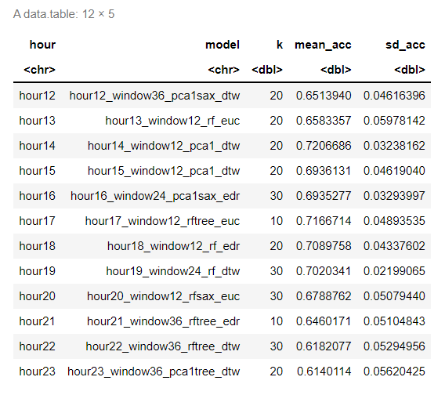

```r
best_models <- character(0)
for(n in 1:nrow(best)){
    k <- paste("k",as.character(best$k[n]),sep="")
    best_models <- c(best_models,paste(best$model[n],k,sep="_"))
}
```

```r
save(best_models,file="C:/Users/kaan9/OneDrive/Masaüstü/best_test.RData")
```

## Prediction and Results Part

For the prediction part, same data manipulation steps are followed.

```r
dt <- fread("C:/Users/kaan9/OneDrive/Masaüstü/bulk_imbalance_son.csv")
total_vol <- data.table(dt[,c("date","hour","downRegulationZeroCoded",
                              "upRegulationZeroCoded","net","system_direction")])
colnames(total_vol) <- c("date","hour","yat_vol","yal_vol","net_imb","direction")
```

```r
wt <- fread("C:/Users/kaan9/OneDrive/Masaüstü/weather_son.csv")
wt$loc <- paste("loc",as.character(wt$lat),as.character(wt$lon),sep="_")
wt <- data.table(pivot_wider(wt[,c(1,2,7,5,6)],names_from = c(loc,variable),values_from =value))
wt$day <- wday(wt$date)
wt$month <- month(wt$date)
total_vol <- wt[total_vol,on=.(date,hour)]
total_vol$t <- 1:nrow(total_vol)
total_vol[, direction:=ifelse(net_imb>50, "Positive" , ifelse(net_imb<(-50),"Negative","Neutral"))]
total_vol[, net_imb:=ifelse(net_imb<(-5000), (-5000), ifelse(net_imb>5000, 5000, net_imb))]
```

```r
pca <- princomp(total_vol[,-c("date","yat_vol","yal_vol","net_imb","direction","t")])
summary(pca)
```

```
Importance of components:
                            Comp.1       Comp.2       Comp.3      Comp.4
Standard deviation     704.3836339 122.42625879 101.36671251 93.81010051
Proportion of Variance   0.8474425   0.02560005   0.01755022  0.01503111
Cumulative Proportion    0.8474425   0.87304257   0.89059278  0.90562389
                            Comp.5      Comp.6      Comp.7       Comp.8
Standard deviation     88.26658029 84.20265311 82.61431247 74.974045479
Proportion of Variance  0.01330713  0.01210998  0.01165742  0.009600937
Cumulative Proportion   0.91893102  0.93104099  0.94269841  0.952299347
                             Comp.9    Comp.10      Comp.11      Comp.12
Standard deviation     70.751694181 68.4074839 61.486591144 56.258304100
Proportion of Variance  0.008549986  0.0079928  0.006457324  0.005405863
Cumulative Proportion   0.960849333  0.9688421  0.975299457  0.980705320
                            Comp.13      Comp.14      Comp.15    Comp.16
Standard deviation     52.018744308 50.106418008 46.557691095 27.3100028
Proportion of Variance  0.004621803  0.004288234  0.003702326  0.0012739
Cumulative Proportion   0.985327123  0.989615357  0.993317683  0.9945916
                            Comp.17      Comp.18      Comp.19      Comp.20
Standard deviation     2.219660e+01 2.168432e+01 1.949563e+01 1.863293e+01
Proportion of Variance 8.415207e-04 8.031251e-04 6.491817e-04 5.929988e-04
Cumulative Proportion  9.954331e-01 9.962362e-01 9.968854e-01 9.974784e-01
                           Comp.21      Comp.22      Comp.23      Comp.24
Standard deviation     17.72753012 1.616528e+01 1.568556e+01 1.316153e+01
Proportion of Variance  0.00053677 4.463323e-04 4.202345e-04 2.958723e-04
Cumulative Proportion   0.99801518 9.984615e-01 9.988817e-01 9.991776e-01
                            Comp.25      Comp.26      Comp.27      Comp.28
Standard deviation     1.121351e+01 1.046030e+01 8.3865734296 7.135328e+00
Proportion of Variance 2.147705e-04 1.868872e-04 0.0001201326 8.696002e-05
Cumulative Proportion  9.993924e-01 9.995793e-01 0.9996994081 9.997864e-01
                            Comp.29      Comp.30      Comp.31      Comp.32
Standard deviation     6.793142e+00 5.735301e+00 3.036780e+00 2.718089e+00
Proportion of Variance 7.881941e-05 5.618291e-05 1.575137e-05 1.261883e-05
Cumulative Proportion  9.998652e-01 9.999214e-01 9.999371e-01 9.999497e-01
                            Comp.33      Comp.34      Comp.35      Comp.36
Standard deviation     2.302360e+00 2.036385e+00 1.992389e+00 1.698923e+00
Proportion of Variance 9.053953e-06 7.082909e-06 6.780163e-06 4.929911e-06
Cumulative Proportion  9.999588e-01 9.999659e-01 9.999727e-01 9.999776e-01
                            Comp.37      Comp.38      Comp.39      Comp.40
Standard deviation     1.553174e+00 1.475619e+00 1.353417e+00 1.277103e+00
Proportion of Variance 4.120330e-06 3.719120e-06 3.128637e-06 2.785758e-06
Cumulative Proportion  9.999817e-01 9.999854e-01 9.999886e-01 9.999913e-01
                            Comp.41      Comp.42      Comp.43      Comp.44
Standard deviation     1.160868e+00 1.097242e+00 1.067046e+00 8.709632e-01
Proportion of Variance 2.301745e-06 2.056349e-06 1.944723e-06 1.295661e-06
Cumulative Proportion  9.999936e-01 9.999957e-01 9.999976e-01 9.999989e-01
                            Comp.45
Standard deviation     7.878287e-01
Proportion of Variance 1.060121e-06
Cumulative Proportion  1.000000e+00
```

```r
total_vol[,pca1:=pca$scores[,1]]
```

```r
date_fltr <- which(total_vol$date=="2022-01-12")[total_vol[which(total_vol$date=="2022-01-12")]$hour==16]
total_vol_train <- total_vol[1:date_fltr,]
```

For the predictions, Random Forest model is trained on the all data available.

```r
start <- Sys.time()
model_rf_all <- randomForest(net_imb ~.-date-yat_vol-yal_vol-direction-t-pca1,total_vol_train)
end <- Sys.time()
save(model_rf_all,file="C:/Users/kaan9/OneDrive/Masaüstü/rf_model_all.Rdata")
```

```r
load("C:/Users/kaan9/OneDrive/Masaüstü/rf_model_all.Rdata")
model_rf_all
```

```
Call:
 randomForest(formula = net_imb ~ . - date - yat_vol - yal_vol -      direction - t - pca1, data = total_vol_train)
               Type of random forest: regression
                     Number of trees: 500
No. of variables tried at each split: 15

          Mean of squared residuals: 378077.6
                    % Var explained: 62.9
```

```r
control1 <- trainControl(method="cv",
                        number=10)
start <- Sys.time()
model_ranger <-  train(net_imb ~.-date-yat_vol-yal_vol-direction-t-pca1,
                       data = total_vol_train,
                       method = 'ranger',
                       metric = 'RMSE',
                       trControl = control1,
                       tuneGrid = expand.grid(.mtry=c(15,25,35),.splitrule="variance",.min.node.size=c(10,30,50)))
end <- Sys.time()
save(model_ranger,file="C:/Users/kaan9/OneDrive/Masaüstü/ranger_model.Rdata")
```

```r
load("C:/Users/kaan9/OneDrive/Masaüstü/ranger_model.Rdata")
model_ranger
```

[output not shown]

```r
control1 <- trainControl(method="cv",
                        number=10)
start <- Sys.time()
model_ranger_son <-  train(net_imb ~.-date-yat_vol-yal_vol-direction-t-pca1,
                       data = total_vol_train,
                       num.trees=500,
                       method = 'ranger',
                       metric = 'RMSE',
                       trControl = control1,
                       tuneGrid = expand.grid(.mtry=15,.splitrule="variance",.min.node.size=3))
end <- Sys.time()
save(model_ranger_son,file="C:/Users/kaan9/OneDrive/Masaüstü/ranger_model_son.Rdata")
```

Ranger and Random Forest packages are trained and parameter tuning is made with cross-validation. Best RF model which will be used to transform data to univariate is shown below.

```r
load("C:/Users/kaan9/OneDrive/Masaüstü/ranger_model_son.Rdata")
model_ranger_son
```

```
Random Forest

26585 samples
   51 predictor

No pre-processing
Resampling: Cross-Validated (10 fold)
Summary of sample sizes: 23926, 23926, 23926, 23926, 23928, 23926, ...
Resampling results:

  RMSE      Rsquared   MAE
  624.4039  0.6715859  454.5149

Tuning parameter 'mtry' was held constant at a value of 15
Tuning
 parameter 'splitrule' was held constant at a value of variance

Tuning parameter 'min.node.size' was held constant at a value of 3
```

```r
series <- list()
start_hours_before <- 0
window_sizes <- c(12,24,36)
cols <- c("rf","pca1")
for(c in cols){
    for(w in window_sizes){
        tmp <- data.table(total_vol)
        tmp[, paste0((start_hours_before):(w+start_hours_before-1), "_hours_before") := shift(tmp[[c]], (start_hours_before):(w+start_hours_before-1))]
        tmp <- tmp[complete.cases(tmp),]
        for(h in 12:23){
           hour <- paste("hour",as.character(h),sep="")
           window <- paste("window",as.character(w),sep="")
           st <- which(colnames(tmp)==paste(start_hours_before,"hours_before",sep="_"))
           e <- length(colnames(tmp))
           dir <- which(colnames(tmp)=="direction")
           indices <- c(1,dir,st:e)
           series[[paste(hour,window,c,sep="_")]]  <- tmp[hour==h,..indices]
        }
    }
}
```

```r
time_start <- Sys.time()
for(n in names(series)){
  series_long <- melt(series[[n]],id.vars = c("date","direction"))
  long_dt <- data.table()
  for(d in unique(series_long$date)){
    temp_dt <- series_long[date==d,]
    temp_tree <- rpart(value~variable,temp_dt,minbucket=1,minsplit=2)
    temp_pred <- predict(temp_tree)
    temp_dt$tree <- temp_pred
    temp_dt[,t:=1:.N]
    temp_sax <- repr_sax(temp_dt$value, q = 2, a = 4)
    dummy_time=c(1:(length(temp_sax)-1))*2
    dummy_time=c(dummy_time,nrow(temp_dt))
    dt_sax=data.table(t=dummy_time,sax_rep_char=temp_sax)
    temp_dt <- merge(temp_dt,dt_sax,by="t",all.x=T)
    temp_dt[,sax_rep_char_num:=nafill(as.numeric(as.factor(sax_rep_char)),'nocb')] # from data.table
    temp_dt[,sax_rep:=mean(value),by=list(sax_rep_char_num)]
    long_dt <- rbind(long_dt,temp_dt)
  }
  series[[paste(n,"tree",sep="")]] <- dcast(long_dt,date+direction~variable,value.var="tree")
  series[[paste(n,"sax",sep="")]] <- dcast(long_dt,date+direction~variable,value.var="sax_rep")
}
time_end <- Sys.time()
```

```r
load("C:/Users/kaan9/OneDrive/Masaüstü/best_test.RData")
load("C:/Users/kaan9/OneDrive/Masaüstü/series_rapor.RData")
```

```r
trainclasses <- list()
for(h in 12:23){
    trainclasses[[as.character(h)]] <- total_vol[hour==h,]$direction
}
```

Time series data is computed with the same steps. “predict_knn” function is shown below and it gives predictions between hour 12 and 23 with the best model information for the desired day.

```r
predict_knn <- function(bestModels,date){

    today <- date
    predictions <- character(0)
    for(n in best_models){
        seri <- substr(n,start = 1,stop=gregexpr(pattern ='_',n)[[1]][3]-1)
        hour <- as.numeric(substr(n,start = 5,stop=gregexpr(pattern ='_',n)[[1]][1]-1))
        dis <- substr(n,start = gregexpr(pattern ='_',n)[[1]][3]+1,stop=gregexpr(pattern ='_',n)[[1]][4]-1)
        k <- as.numeric(substr(n,start = gregexpr(pattern ='_',n)[[1]][4]+2,stop=nchar(n)))
        train_class <- trainclasses[[as.character(hour)]]

        if(dis=="edr"){
           dist_matrix <- TSDatabaseDistances(X = series[[seri]][,3:length(series[[seri]])],
                                              Y = series[[seri]][date==today,3:length(series[[seri]])],
                                              distance='erp',g=0.5)
        }else if(dis=="dtw"){
            dist_matrix <- dtwDist(mx=series[[seri]][,3:length(series[[seri]])],
                                   my=series[[seri]][date==today,3:length(series[[seri]])],
                                   window.type='sakoechiba',window.size=10)
        }else if(dis=="euc"){
            dist_matrix <- TSDatabaseDistances(X = series[[seri]][,3:length(series[[seri]])],
                                               Y = series[[seri]][date==today,3:length(series[[seri]])],
                                               distance='euc')
        }

        dist_matrix[length(dist_matrix)] <- 1000000
        ordered_indices <- order(dist_matrix)
        nearest_class <- train_class[ordered_indices[1:k]]
        tmp_table <- table(nearest_class)
        pred <- names(which.max(tmp_table))
        predictions <- c(predictions,pred)
    }
    return(predictions)

}
```

```r
predict_knn(best_models,"2022-01-22")
```

1. ‘Negative’
2. ‘Positive’
3. ‘Positive’
4. ‘Positive’
5. ‘Positive’
6. ‘Positive’
7. ‘Positive’
8. ‘Positive’
9. ‘Positive’
10. ‘Positive’
11. ‘Positive’
12. ‘Positive’

After the competition period ends, all period is predicted again.

```r
total_vol[hour %in% c(12:23),][(date=="2022-01-22"),]$direction <- rep("Positive",12)
```

```r
test_start <- "2022-01-09"
test_end <- "2022-01-22"
test_dates <- unique(total_vol[hour %in% c(12:23),][(date>=test_start) & (date<=test_end),date])
real <- total_vol[hour %in% c(12:23),][(date>=test_start) & (date<=test_end),direction]
```

```r
preds <- character(0)
for(d in test_dates){
    preds <- c(preds,predict_knn(best_models,d))
}
```

```r
res_dt <- total_vol[hour %in% c(12:23),][(date>=test_start) & (date<=test_end),c("date","hour","direction")]
res_dt[,preds:=preds]
```

```r
accu <- numeric(0)
for(d in test_dates){
    real_temp <- res_dt[date==d,direction]
    pred_temp <- res_dt[date==d,preds]
    accu <- c(accu,Metrics::accuracy(actual = real_temp,predicted = pred_temp))
}
```

The final results are shown in the table below, daily accuracies of every day in the test period. Overall accuracy in the test period is 0.744.

```r
res_son <- data.table("date"=test_dates,"Daily Accuracy"=accu)
res_son
```

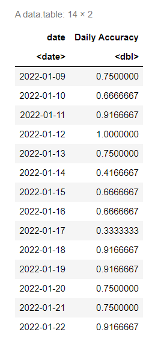

```r
mean(accu)
```

0.744047619047619

Baseline accuracy for the test period is shown below.

```r
baseline_accuracy_daily = function(dat, start_date, end_date){

    dat[, baseline1_prediction:=shift(direction, n=24, type="lag")]
    dat[, baseline2_prediction:=shift(direction, n=168, type="lag")]

    dat = dat[date>=start_date & date<=end_date & hour>=12]

    dat[,result_1:=ifelse(direction==baseline1_prediction, 1, 0)]
    dat[,result_2:=ifelse(direction==baseline2_prediction, 1, 0)]

    daily_summary = dat[,list(Baseline1_Daily_Accuracy=mean(result_1),
                              Baseline2_Daily_Accuracy=mean(result_2)), c("date")]

    return(daily_summary)

}

baseline_accuracy_daily(total_vol, as.Date("2022-01-09"), as.Date("2022-01-22"))
```

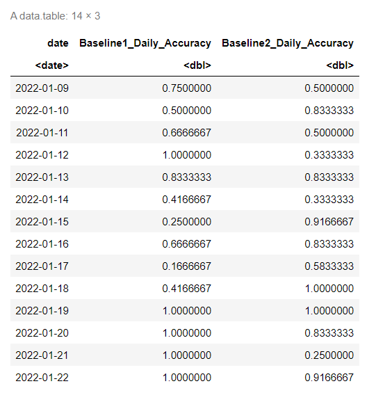

Comparasion between baselines and model predictions by daily accuracy are shown below in the table.

```r
final_res <- baseline_accuracy_daily(total_vol, as.Date("2022-01-09"), as.Date("2022-01-22"))
final_res$Model_Daily_Accuracy <- res_son$`Daily Accuracy`
final_res$date <- as.character(final_res$date)
rbind(final_res,list("Mean",mean(final_res$Baseline1_Daily_Accuracy),
                     mean(final_res$Baseline2_Daily_Accuracy),mean(final_res$Model_Daily_Accuracy)))
```

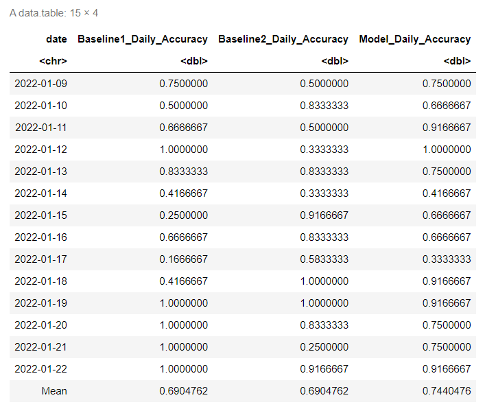

```r
baseline_accuracy_hourly = function(dat, start_date, end_date){

    dat[, baseline1_prediction:=shift(direction, n=24, type="lag")]
    dat[, baseline2_prediction:=shift(direction, n=168, type="lag")]

    dat = dat[date>=start_date & date<=end_date & hour>=12]

    dat[,result_1:=ifelse(direction==baseline1_prediction, 1, 0)]
    dat[,result_2:=ifelse(direction==baseline2_prediction, 1, 0)]

    daily_summary = dat[,list(Baseline1_Hourly_Accuracy=mean(result_1),
                              Baseline2_Hourly_Accuracy=mean(result_2)), c("hour")]

    return(daily_summary)

}

hourly_dt <- baseline_accuracy_hourly(total_vol, as.Date("2022-01-09"), as.Date("2022-01-22"))
```

Comparasion between baselines and model predictions by hourly accuracy are shown below in the table.

```r
hourly_acc <- numeric(0)
for(h in 12:23){
    hourly_acc <- c(hourly_acc,Metrics::accuracy(actual = res_dt[hour==h,direction],predicted = res_dt[hour==h,preds]))
}
hourly_dt$Model_Hourly_Accuracy <- hourly_acc
hourly_dt
```

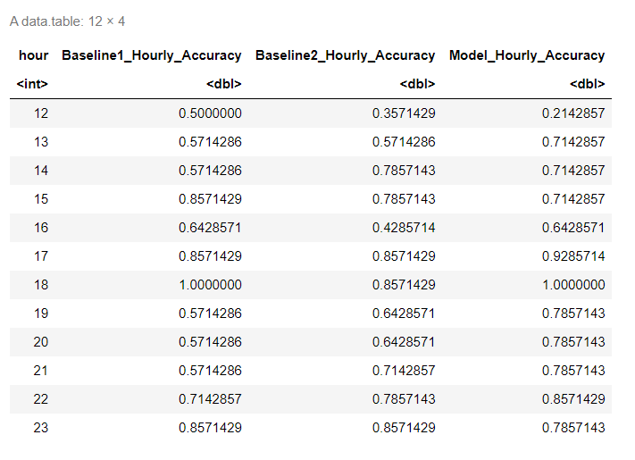